# Tarea 2_2

Oscar Montenegro

2023-09-03

# Tarea 2_2

Para cada variable, dentro de la temporada 2 (Polarizado) comparar los mesociclos de Carga, Potencia y Competencia. Equivalente a comparar 3 muestras.

# Procedimiento

## ¿Medidas independientes o autocorrelacionadas?

El primer paso es hacer un test de autocorrelación en cada caso, para determinar si se usa análisis de medidas independientes o series de tiempo interrumpidas (STI). Se usó la prueba de Pearson.

## Medidas independientes

La prueba empleada para comparar las variables de medidas independientes (no correlacionadas) depende de la distribución de probabilidad de las observaciones (normalidad), para determinar esto, se aplicó la prueba Shapiro-Wilk.

Las variables que cumplen el supuesto de normalidad, son evaluadas con la prueba de de varianzas de Barlett para clasificarlas como homocedásticas o heterocedásticas.

### Homocedásticas

A las variables homocedásticas se les aplica la prueba ANOVA para saber si hay muestras (mesotipos) con diferencias significativas en sus medias. En caso de haber alguna, se hace análisis post-hoc con la prueba de Tukey para identificar los mesotipos con diferencias.

### Heterocedásticas

A las variables heterocedásticas se les aplica la prueba ANOVA de una vía para saber si hay muestras (mesotipos) con diferencias significativas en sus medias. En caso de haber alguna, se hace análisis post-hoc con la prueba de Games-Howell para identificar los mesotipos con diferencias.

### No Paramétricas

A las variables que no cumplen el supuesto de normalidad, son evaluadas con la prueba de WKruskal-Wallis para saber si hay muestras (mesotipos) con diferencias significativas en sus medianas. En caso de haber alguna, se hace análisis post-hoc con el test de Dunn para identificar los mesotipos con diferencias.

# Resultados

## Test de autocorrelación

|  | MesoTipo | var1 | cor | p | autocorrelacion |
| --- | --- | --- | --- | --- | --- |
| 1 | Carga | ACWR | -0.25 | 0.229 | 0 |
| 2 | Potencia | ACWR | -0.42 | 0.412 | 0 |
| 3 | Competencia | ACWR | -0.34 | 0.451 | 0 |
| 4 | Carga | ATL | 0.044 | 0.822 | 0 |
| 5 | Potencia | ATL | 0.095 | 0.807 | 0 |
| 6 | Competencia | ATL | -0.26 | 0.461 | 0 |
| 7 | Carga | CTL | 0.77 | 7.51e-06 | 1 |
| 8 | Potencia | CTL | 0.8 | 0.0537 | 1 |
| 9 | Competencia | CTL | 0.59 | 0.165 | 0 |
| 10 | Carga | TMI | 0.19 | 0.344 | 0 |

[output cut: 38 more lines]

|  | LaVariable | auto_Carga | auto_Competencia | auto_Potencia | Suma | Criterio | Analisis |
| --- | --- | --- | --- | --- | --- | --- | --- |
| 1 | ACWR | 0 | 0 | 0 | 0 | Indep | Medias |
| 2 | ATL | 0 | 0 | 0 | 0 | Indep | Medias |
| 3 | CTL | 1 | 0 | 1 | 2 | Dep | STI |
| 4 | TMI | 0 | 0 | 0 | 0 | Indep | Medias |
| 5 | TRIMP_BC_Micro | 0 | 0 | 0 | 0 | Indep | Medias |
| 6 | TRIMP_MOR_Micro | 0 | 0 | 0 | 0 | Indep | Medias |
| 7 | TS | 0 | 0 | 0 | 0 | Indep | Medias |
| 8 | W_FCT | 0 | 0 | 0 | 0 | Indep | Medias |
| 9 | W_RFC | 0 | 0 | 0 | 0 | Indep | Medias |
| 10 | W_S_RPE | 0 | 0 | 0 | 0 | Indep | Medias |

[output cut: 6 more lines]

## Medidas independientes

### Prueba de normalidad

Tabla_Df_prueba_normal_T2

|  | LaVariable | MesoTipo | statistic | p | normalidad |
| --- | --- | --- | --- | --- | --- |
| 1 | ACWR | Carga | 0.9374147838728006 | 0.1164945874366834 | 1 |
| 2 | ACWR | Potencia | 0.9781600519078559 | 0.9501403993012489 | 1 |
| 3 | ACWR | Competencia | 0.9030450435200261 | 0.3076708243561096 | 1 |
| 4 | ATL | Carga | 0.9052710609559826 | 0.01313127140456563 | 0 |
| 5 | ATL | Potencia | 0.9382715628298465 | 0.5339459074514314 | 1 |
| 6 | ATL | Competencia | 0.9561684848025188 | 0.7231632082206664 | 1 |
| 7 | TMI | Carga | 0.9326479590503255 | 0.06444127951827879 | 1 |
| 8 | TMI | Potencia | 0.9407782121336726 | 0.5617049140778746 | 1 |
| 9 | TMI | Competencia | 0.804128831573691 | 0.01066115540331162 | 0 |
| 10 | TRIMP_BC_Micro | Carga | 0.964713569448566 | 0.426734068343793 | 1 |

[output cut: 32 more lines]

Tabla_medias_prueba_T2

|  | LaVariable | norm_Carga | norm_Competencia | norm_Potencia | Suma | Tipo | Prueba |
| --- | --- | --- | --- | --- | --- | --- | --- |
| 1 | ACWR | 1 | 1 | 1 | 3 | Paramétrica | Anova |
| 2 | ATL | 0 | 1 | 1 | 2 | No-Paramétrica | Kruskal |
| 3 | TMI | 1 | 0 | 1 | 2 | No-Paramétrica | Kruskal |
| 4 | TRIMP_BC_Micro | 1 | 1 | 1 | 3 | Paramétrica | Anova |
| 5 | TRIMP_MOR_Micro | 1 | 1 | 1 | 3 | Paramétrica | Anova |
| 6 | TS | 0 | 1 | 1 | 2 | No-Paramétrica | Kruskal |
| 7 | W_FCT | 1 | 1 | 1 | 3 | Paramétrica | Anova |
| 8 | W_RFC | 1 | 1 | 1 | 3 | Paramétrica | Anova |
| 9 | W_S_RPE | 1 | 1 | 1 | 3 | Paramétrica | Anova |
| 10 | W_S_RPE_mean | 1 | 1 | 1 | 3 | Paramétrica | Anova |

[output cut: 4 more lines]

### Paramétricas - Prueba de Varianzas

|  | LaVariable | p_value_var | Tipo |
| --- | --- | --- | --- |
| 1 | ACWR | 0.5468342382421644 | Homocedastica |
| 2 | TRIMP_BC_Micro | 0.5911050245155424 | Homocedastica |
| 3 | TRIMP_MOR_Micro | 0.5911050245155586 | Homocedastica |
| 4 | W_FCT | 0.8449895268193285 | Homocedastica |
| 5 | W_RFC | 0.895797439441607 | Homocedastica |
| 6 | W_S_RPE | 0.8208294582656651 | Homocedastica |
| 7 | W_S_RPE_mean | 0.8177739072178684 | Homocedastica |
| 8 | W_TLRPE | 0.02316513777267999 | Heterocedastica |
| 9 | W_VOLU | 0.4318741799970085 | Homocedastica |

### Paramétricas - Homocedásticas - ANOVA

|  | LaVariable | Effect | DFn | DFd | F | p | p<.05 | ges | dif_sig |
| --- | --- | --- | --- | --- | --- | --- | --- | --- | --- |
| 1 | ACWR | MesoTipo | 2 | 38 | 1.039 | 0.364 |  | 0.052 | 0 |
| 2 | TRIMP_BC_Micro | MesoTipo | 2 | 47 | 0.471 | 0.627 |  | 0.02 | 0 |
| 3 | TRIMP_MOR_Micro | MesoTipo | 2 | 47 | 0.471 | 0.627 |  | 0.02 | 0 |
| 4 | W_FCT | MesoTipo | 2 | 47 | 2.276 | 0.114 |  | 0.088 | 0 |
| 5 | W_RFC | MesoTipo | 2 | 47 | 1.753 | 0.184 |  | 0.069 | 0 |
| 6 | W_S_RPE | MesoTipo | 2 | 47 | 0.143 | 0.867 |  | 0.006 | 0 |
| 7 | W_S_RPE_mean | MesoTipo | 2 | 47 | 0.669 | 0.517 |  | 0.028 | 0 |
| 8 | W_VOLU | MesoTipo | 2 | 47 | 0.233 | 0.793 |  | 0.01 | 0 |

### Homocedásticas - Post-hoc

Prueba de Tukey NO HAY

### Paramétricas - Heterocedásticas - ANOVA de una vía

[output not shown]

### Heterocedásticas - Post-hoc

Games-Howell

|  | LaVariable | .y. | group1 | group2 | estimate | conf.low | conf.high | p.adj | p.adj.signif | dif_sig | etiqueta |
| --- | --- | --- | --- | --- | --- | --- | --- | --- | --- | --- | --- |
| 1 | W_TLRPE | medicion | Carga | Competencia | -11.90108259600031 | -28.91098454479308 | 5.108819352792466 | 0.211 | ns | 0 | 0.211 ns |
| 2 | W_TLRPE | medicion | Carga | Potencia | 21.59852776409414 | -15.17201958222638 | 58.36907511041467 | 0.293 | ns | 0 | 0.293 ns |
| 3 | W_TLRPE | medicion | Competencia | Potencia | 33.49961036009445 | -3.580388892902562 | 70.57960961309146 | 0.078 | ns | 0 | 0.078 ns |

Gráficas

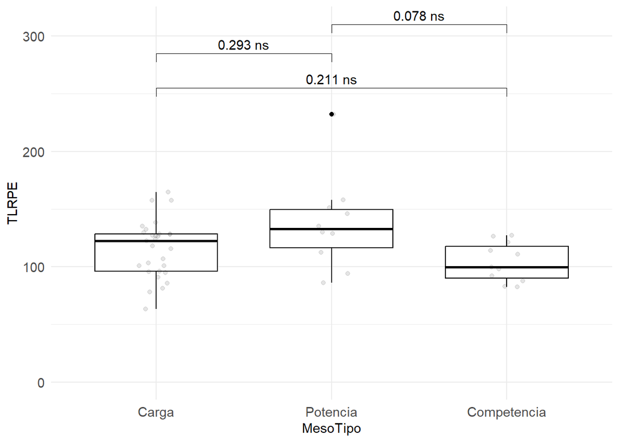

### No Paramétricas - Prueba de Kruskal-Wallis

|  | LaVariable | .y. | n | statistic | df | p | method | dif_sig |
| --- | --- | --- | --- | --- | --- | --- | --- | --- |
| 1 | ATL | medicion | 50 | 0.8059952056057682 | 2 | 0.668 | Kruskal-Wallis | 0 |
| 2 | TMI | medicion | 50 | 11.1206402360317 | 2 | 0.00385 | Kruskal-Wallis | 1 |
| 3 | TS | medicion | 50 | 9.146847132583446 | 2 | 0.0103 | Kruskal-Wallis | 1 |
| 4 | z1 | medicion | 50 | 0.2441091056681549 | 2 | 0.885 | Kruskal-Wallis | 0 |
| 5 | z2 | medicion | 50 | 4.959733213864211 | 2 | 0.0838 | Kruskal-Wallis | 0 |

### No Paramétricas - Post-hoc

Prueba de Dunn

|  | LaVariable | .y. | group1 | group2 | n1 | n2 | statistic | p | p.adj | p.adj.signif | dif_sig | etiqueta |
| --- | --- | --- | --- | --- | --- | --- | --- | --- | --- | --- | --- | --- |
| 1 | TMI | medicion | Carga | Competencia | 29 | 11 | -3.331585773388325 | 0.0008635268443881033 | 0.003 | ** | 1 | 0.003 ** |
| 2 | TMI | medicion | Carga | Potencia | 29 | 10 | -1.024974657402548 | 0.3053751456100009 | 0.916 | ns | 0 | 0.916 ns |
| 3 | TMI | medicion | Competencia | Potencia | 11 | 10 | 1.839786637467265 | 0.06579956799460157 | 0.197 | ns | 0 | 0.197 ns |
| 4 | TS | medicion | Carga | Competencia | 29 | 11 | -2.981180197149706 | 0.00287139778850038 | 0.009 | ** | 1 | 0.009 ** |
| 5 | TS | medicion | Carga | Potencia | 29 | 10 | -0.3005904281621064 | 0.763726831318196 | 1 | ns | 0 | 1 ns |
| 6 | TS | medicion | Competencia | Potencia | 11 | 10 | 2.163783198138382 | 0.03048099222693993 | 0.091 | ns | 0 | 0.091 ns |

Gráfica

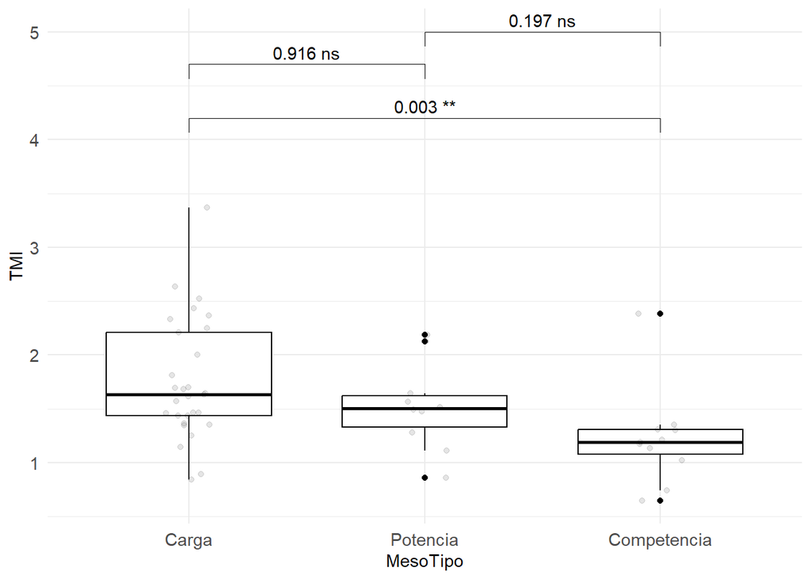

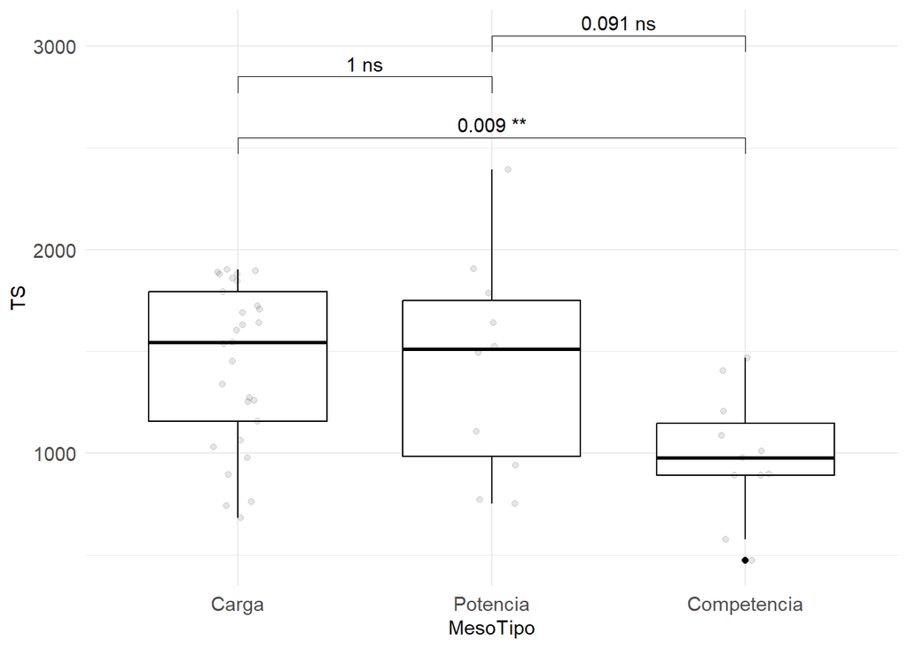

## Autocorrelacionadas -STI

### Resúmen de modelos

|  | Temporada | LaVariable | term | estimate | std.error | statistic | p.value | p.value.signif | cr_sig | cambio |
| --- | --- | --- | --- | --- | --- | --- | --- | --- | --- | --- |
| 1 | Polarizado | CTL | (Intercept) | 629.9090017094023 | 41.2902739053995 | 15.25562661930004 | 4.918724820446154e-17 | *** |  |  |
| 2 | Polarizado | CTL | tiempo | 14.37955156695155 | 2.278138255074222 | 6.31197493607914 | 3.003755344266492e-07 | *** |  |  |
| 3 | Polarizado | CTL | intervencion_1 | -684.3686161986159 | 124.3789126662851 | -5.502288141357301 | 3.499811725116579e-06 | *** | sí | nivel |
| 4 | Polarizado | CTL | tiempoInterv_1 | 70.67544843304843 | 16.62137896302659 | 4.252080924829543 | 0.0001496631615638996 | *** | sí | tendencia |
| 5 | Polarizado | CTL | intervencion_2 | -161.9540476190479 | 120.9889975785351 | -1.338584919789272 | 0.1893365162201097 |  | no |  |
| 6 | Polarizado | CTL | tiempoInterv_2 | -112.5431944444444 | 21.2556002315982 | -5.294754945435026 | 6.571859876630685e-06 | *** | sí | tendencia |
| 7 | Polarizado | z3 | (Intercept) | 0.1420244592664167 | 0.04748519625907933 | 2.990920759630665 | 0.004543486764379532 | ** |  |  |
| 8 | Polarizado | z3 | tiempo | 0.0007166350517928521 | 0.002764695014143778 | 0.2592094419553156 | 0.7966825656940115 |  |  |  |
| 9 | Polarizado | z3 | intervencion_1 | 0.07638676033498612 | 0.09630244063588168 | 0.7931965153801606 | 0.4319199714234263 |  | no |  |
| 10 | Polarizado | z3 | tiempoInterv_1 | -0.00797482301911799 | 0.01399002897135713 | -0.5700362047459275 | 0.5715525148745046 |  | no |  |

[output cut: 2 more lines]

### Tabla Cambios

Tabla 1

| Temporada | LaVariable | Carga_Potencia | Potencia_Competencia |
| --- | --- | --- | --- |
| Polarizado | CTL | Nivel_Tendencia | Tendencia |
| Polarizado | z3 | No | No |

Tabla 2

| Temporada | LaVariable | Carga_Potencia | Potencia_Competencia |
| --- | --- | --- | --- |
| Polarizado | CTL | sí | sí |
| Polarizado | z3 | no | no |

Gráficas (todas)

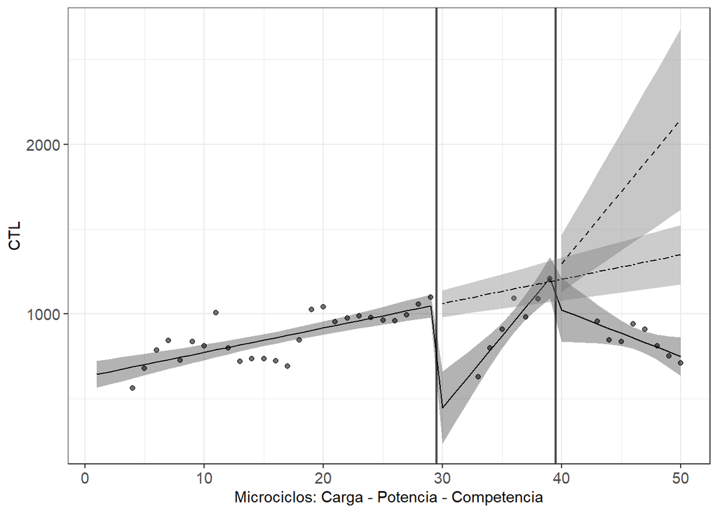

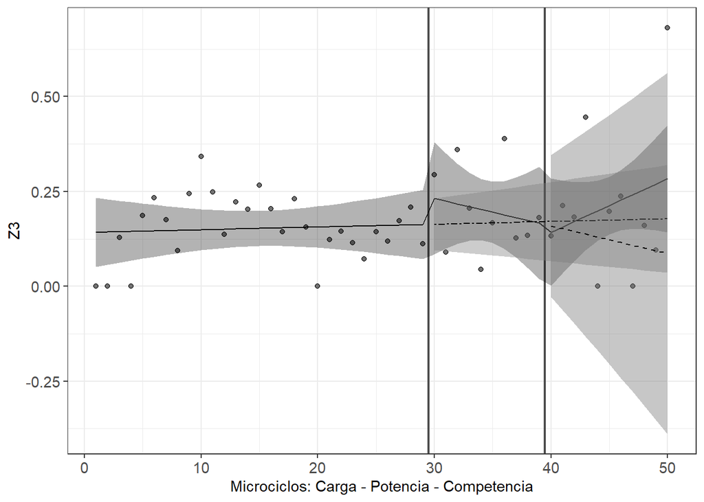

# Independientes - Gráficas de cajas

Todas. Ojo, las gráficas de diferencias significativas están arriba pero acá abajo también están pero sin marcas de las pruebas de comparación.

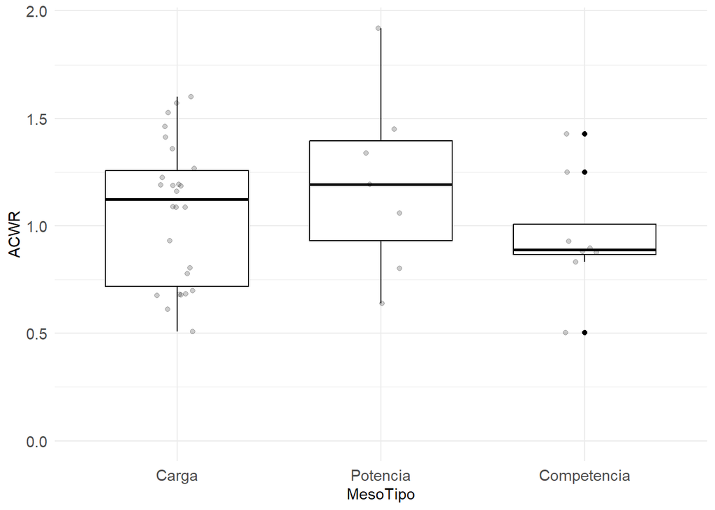

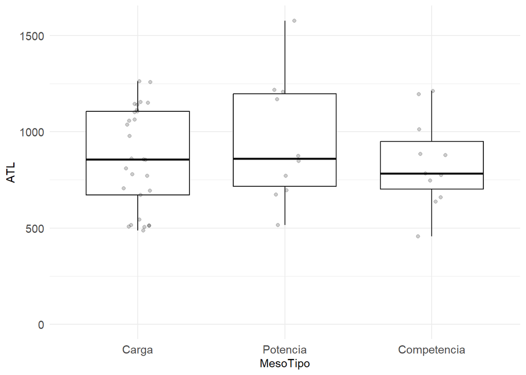

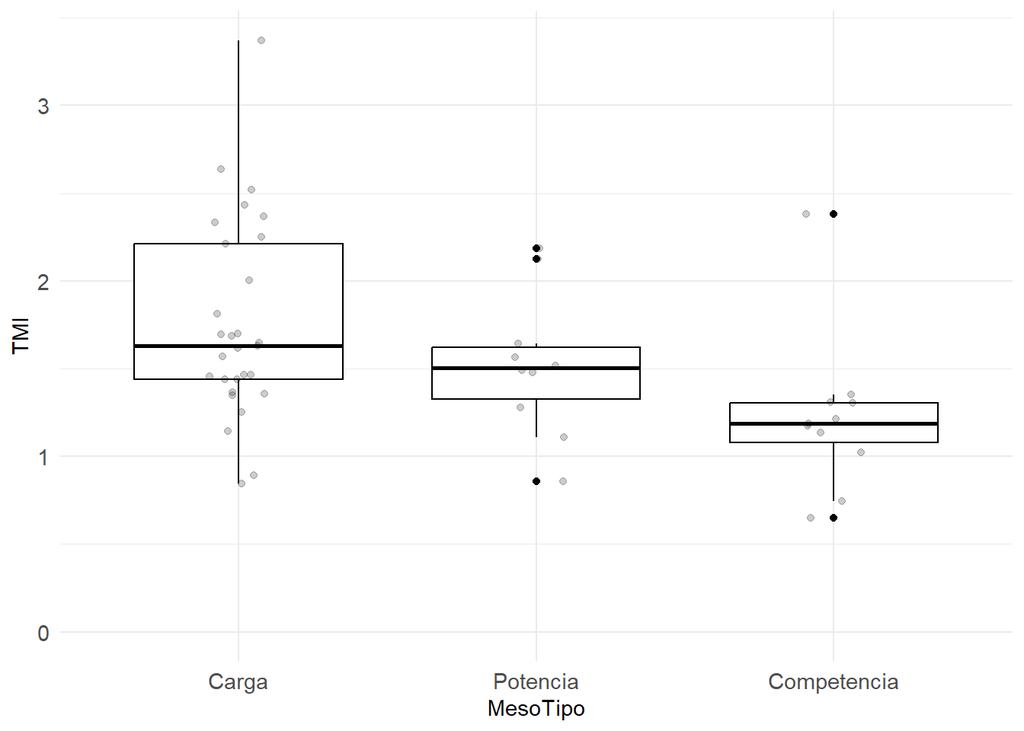

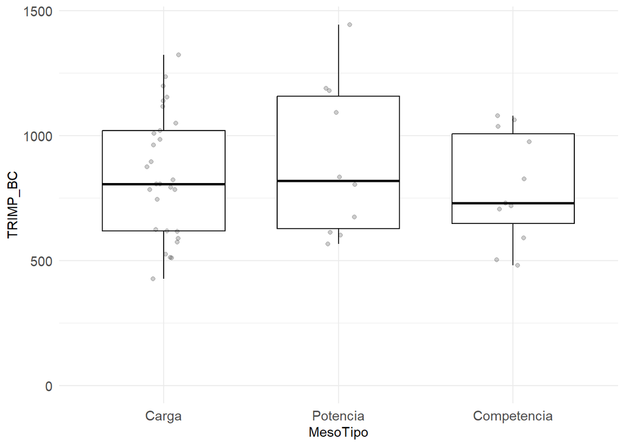

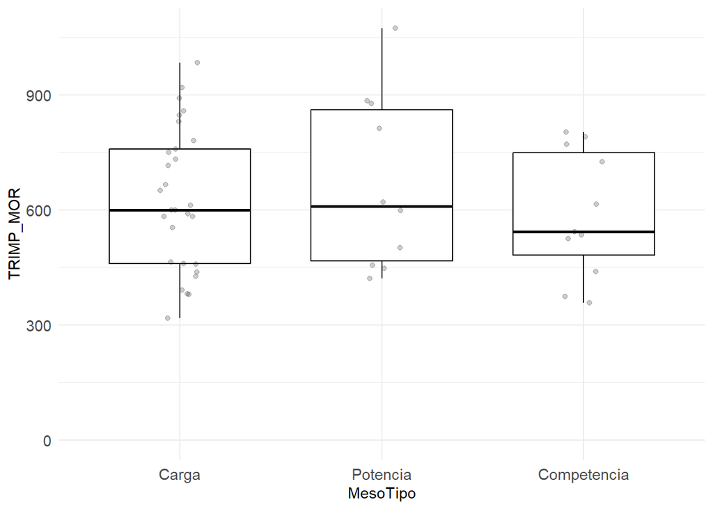

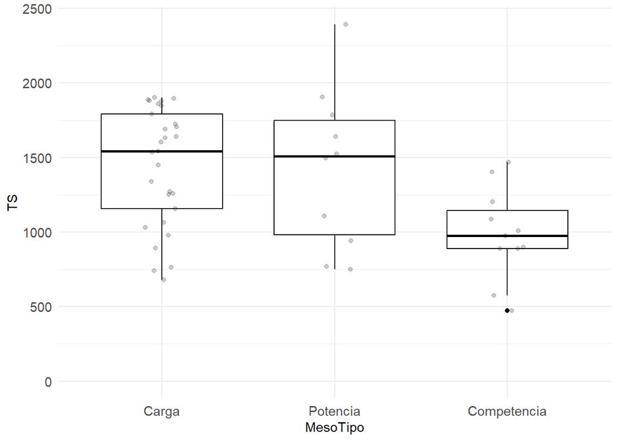

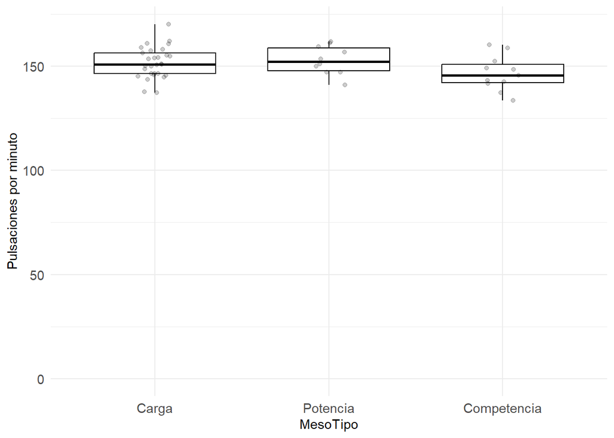

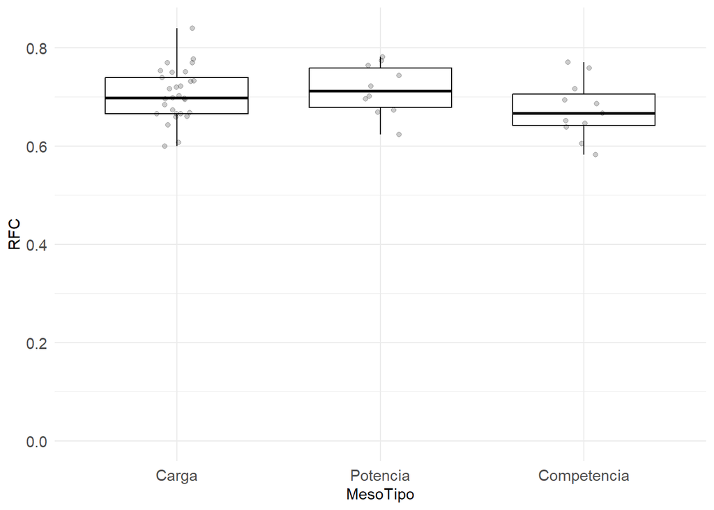

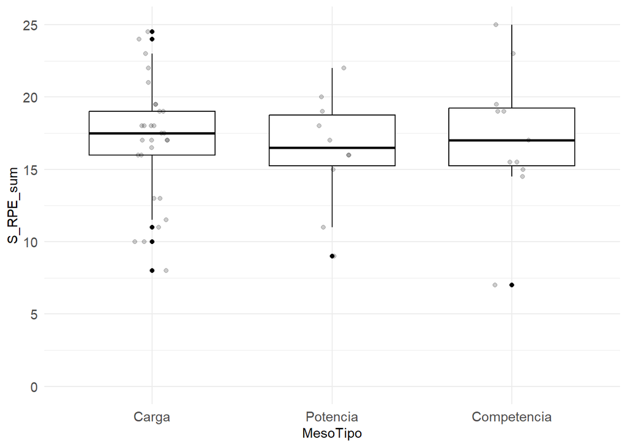

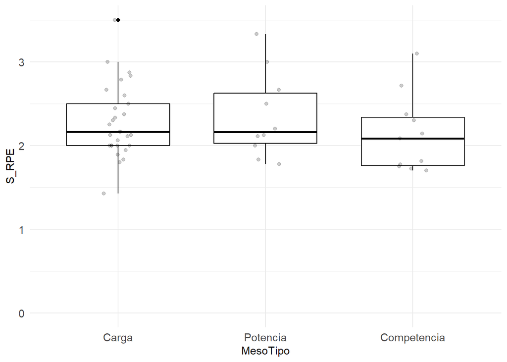

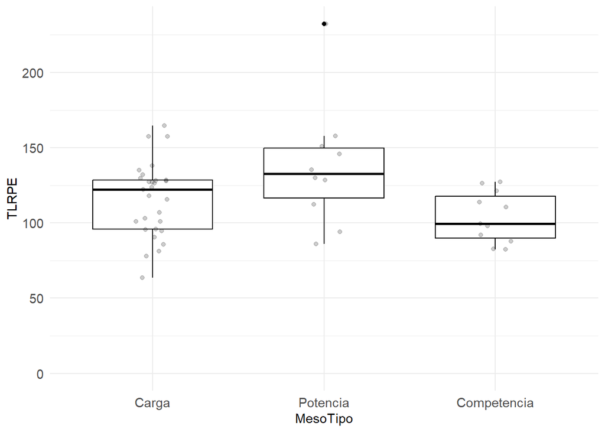

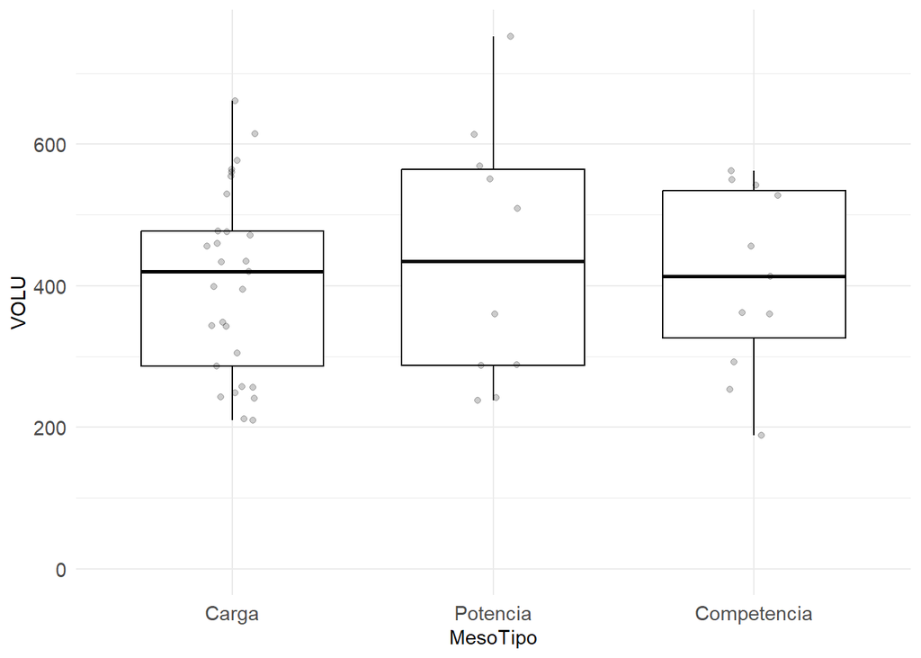

[2 more figures not shown]